# 时间序列问题研究Task1

# 1 Task 1 序列稳定性检验方法汇总

稳定性的数学定义： 假定某个时间序列是由某一随机过程生成的，如果满足以下条件：

1. 均值 $E(X_t) = \mu$ 是与时间t无关的常数
2. 方差 $Var(X_t) = \sigma ^ 2$ 是与时间无关的常数
3. 协方差$Cov(X_t,X_{t-1} ) = \gamma_k$ 只与时间间隔$k$有关与时间$t$无关的常数

则该时间序列是宽平稳的

## 1.1 数据图形化检验

图形化分析是最简单，最基本的方法，直接绘制数据的时序图，用肉眼判断。

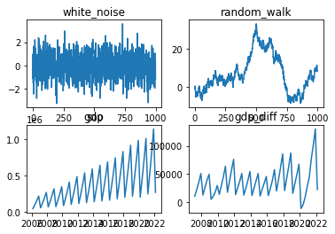

```python
import numpy as np
import pandas as pd
import akshare as ak
from matplotlib import pyplot as plt

np.random.seed(123)

# -------------- 准备数据 --------------
# 白噪声
white_noise = np.random.standard_normal(size=1000)

# 随机游走
x = np.random.standard_normal(size=1000)
random_walk = np.cumsum(x)

# GDP
df = ak.macro_china_gdp()
df = df.set_index('季度')
df.index = pd.to_datetime(df.index)
gdp = df['国内生产总值-绝对值'][::-1].astype('float')

# GDP DIFF
gdp_diff = gdp.diff(4).dropna()


# -------------- 绘制图形 --------------
fig, ax = plt.subplots(2, 2)

ax[0][0].plot(white_noise)
ax[0][0].set_title('white_noise')
ax[0][1].plot(random_walk)
ax[0][1].set_title('random_walk')

ax[1][0].plot(gdp)
ax[1][0].set_title('gdp')
ax[1][1].plot(gdp_diff)
ax[1][1].set_title('gdp_diff')

plt.show()
```

该方法虽然直观，但是具有一定的主观性，在数据相对好观察的时候可以使用。

## 1.2 统计特征可视化检验

可视化统计特征，是指绘制时间序列的自相关图和偏自相关图，根据自相关图的表现来判断序列是否平稳。

自相关，也叫序列相关，是一个信号与自身不同时间点的相关度，或者说与自身的延迟拷贝–或滞后–的相关性，是延迟的函数。不同滞后期得到的自相关系数，叫自相关图。

（这里有一个默认假设，即序列是平稳的，平稳序列的自相关性只和时间间隔k有关，不随时间t的变化而变化，因而可以称自相关函数是延迟（k）的函数）

平稳序列通常具有短期相关性，**对于平稳的时间序列，自相关系数往往会迅速退化到零（滞后期越短相关性越高，滞后期为0时，相关性为1）；而对于非平稳的数据，退化会发生得更慢，或存在先减后增或者周期性的波动等变动。**

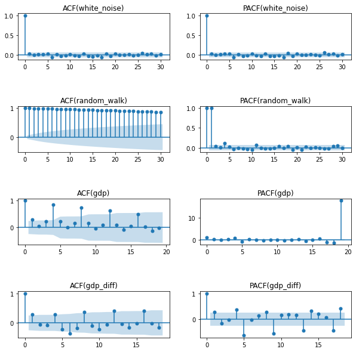

```python
# 数据生成过程在第一个代码块中
from statsmodels.graphics.tsaplots import plot_acf, plot_pacf

fig, ax = plt.subplots(4, 2,figsize = (10,10))
fig.subplots_adjust(hspace=1,wspace=0.2)

plot_acf(white_noise, ax=ax[0][0])
ax[0][0].set_title('ACF(white_noise)')
plot_pacf(white_noise, ax=ax[0][1])
ax[0][1].set_title('PACF(white_noise)')

plot_acf(random_walk, ax=ax[1][0])
ax[1][0].set_title('ACF(random_walk)')
plot_pacf(random_walk, ax=ax[1][1])
ax[1][1].set_title('PACF(random_walk)')

plot_acf(gdp, ax=ax[2][0])
ax[2][0].set_title('ACF(gdp)')
plot_pacf(gdp, ax=ax[2][1])
ax[2][1].set_title('PACF(gdp)')

plot_acf(gdp_diff, ax=ax[3][0])
ax[3][0].set_title('ACF(gdp_diff)')
plot_pacf(gdp_diff, ax=ax[3][1])
ax[3][1].set_title('PACF(gdp_diff)')

plt.show()
```

## 1.3 简单统计方法

计算统计量的方法只是作为一个补充，了解即可。宽平稳中有两个条件是均值不变和方差不变，可视化数据中我们可以直观看出来，其实还可以具体计算一下看看。

直接将序列前后拆分成2个序列，分别计算这2个序列的均值、方差，对比看是否差异明显。

我们来算白噪声和随机游走序列不同时间段的均值、方差：

```python
import numpy as np

np.random.seed(123)

white_noise = np.random.standard_normal(size=1000)

x = np.random.standard_normal(size=1000)
random_walk = np.cumsum(x)

def describe(X):
    split = int(len(X) / 2)
    X1, X2 = X[0:split], X[split:]
    mean1, mean2 = X1.mean(), X2.mean()
    var1, var2 = X1.var(), X2.var()
    print('mean1=%f, mean2=%f' % (mean1, mean2))
    print('variance1=%f, variance2=%f' % (var1, var2))

print('white noise sample')
describe(white_noise)

print('random walk sample')
describe(random_walk)
```

```
white noise sample
mean1=-0.038644, mean2=-0.040484
variance1=1.006416, variance2=0.996734
random walk sample
mean1=5.506570, mean2=8.490356
variance1=53.911003, variance2=126.866920
```

白噪声序列均值和方差略有不同，但大致在同一水平线上； 随机游走序列的均值和方差差异就比较大，因此为非平稳序列。

## 1.4 假设检验方法

平稳的定量检验方法当前主流为假设检验方法，检验序列中是否存在单位根，若存在，为非平稳序列，不存在即为平稳序列。

### 1.4.1 DF检验

ADF检验（Augmented Dickey-Fuller Testing）是最常用的单位根检验方法之一，通过检验序列是否存在单位根来判断序列是否是平稳的。ADF检验是DF检验的增强版，首先看一下DF检验。

迪基（Dickey）和弗勒（Fuller）1979年基于非平稳序列的基本特征将其大致归为三类并提出DF检验：

(1)当序列基本走势呈现无规则上升或下降并反复时，将其归为无漂移项自回归过程；

2. 当序列基本走势呈现明显的随时间递增或递减且趋势并不太陡峭时，将其归为带漂移项自回归过程；
3. 当序列基本走势随时间快速递增时，则将其归为带趋势项回归过程。

原假设：$H_0 : p = 1$ 存在单位根，时间序列为非平稳

备择假设： $ H_1 : p < 1 $ 不存在单位根，时间序列是平稳的

若检验统计量大于临界值（p值大于显著性水平 $\alpha$），不能拒绝原假设，序列是非平稳的；

若检验统计量小于临界值（p值小于显著性水平 $\alpha$），拒绝原假设，认为序列是平稳的。

生成一个平稳序列。

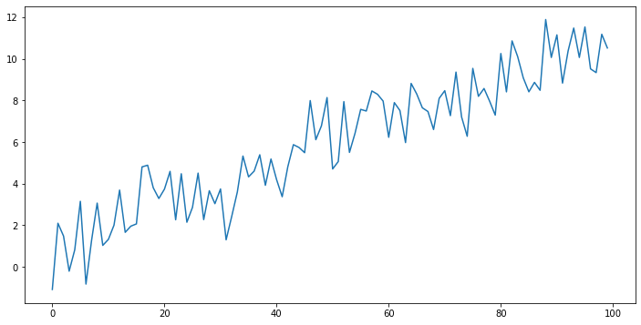

```python
import numpy as np
from matplotlib import pyplot as plt

np.random.seed(123)

y = np.random.standard_normal(size=100)
for i in range(1, len(y)):
    y[i] = 1 + 0.1*i + y[i]

plt.figure(figsize=(12, 6))
plt.plot(y)
plt.show()
```

检验该序列是否平稳

```python
from arch.unitroot import ADF
adf = ADF(y)
# print(adf.pvalue)
print(adf.summary().as_text())

adf = ADF(y,trend='ct')
#adf.trend = 'ct'
print(adf.summary().as_text())
```

```
   Augmented Dickey-Fuller Results
=====================================
Test Statistic                 -0.739
P-value                         0.836
Lags                                5
-------------------------------------

Trend: Constant
Critical Values: -3.50 (1%), -2.89 (5%), -2.58 (10%)
Null Hypothesis: The process contains a unit root.
Alternative Hypothesis: The process is weakly stationary.
   Augmented Dickey-Fuller Results
=====================================
Test Statistic                 -9.963
P-value                         0.000
Lags                                0
-------------------------------------

Trend: Constant and Linear Time Trend
Critical Values: -4.05 (1%), -3.46 (5%), -3.15 (10%)
Null Hypothesis: The process contains a unit root.
Alternative Hypothesis: The process is weakly stationary.
```

arch包中ADF检验可指定trend为:

‘n’（不含截距项和时间趋势项）  
‘c’（含截距项）  
‘ct’（含截距项和时间趋势项）  
‘ctt’（含截距项和时间趋势项和二次型时间趋势项）  
分别对应不同平稳类型的检验。（滞后期lags默认为AIC最小）

以上第一个文本输出中，不指定trend默认为检验是否含截距项平稳，显著性水平p=0.836>0.05，不拒绝原假设，非平稳；  
以上第二个文本输出中，指定trend为检验是否含截距项和时间趋势项平稳，显著性水平p=0.000<0.05，拒绝原假设，故为趋势项平稳。

检验GDP数据使用季节差分后是否平稳

```python
from arch.unitroot import ADF
adf = ADF(gdp)
print(adf.summary().as_text())

adf = ADF(gdp_diff)
print(adf.summary().as_text())
```

```
   Augmented Dickey-Fuller Results
=====================================
Test Statistic                  1.868
P-value                         0.998
Lags                                7
-------------------------------------

Trend: Constant
Critical Values: -3.55 (1%), -2.91 (5%), -2.59 (10%)
Null Hypothesis: The process contains a unit root.
Alternative Hypothesis: The process is weakly stationary.
   Augmented Dickey-Fuller Results
=====================================
Test Statistic                 -2.655
P-value                         0.082
Lags                                8
-------------------------------------

Trend: Constant
Critical Values: -3.56 (1%), -2.92 (5%), -2.60 (10%)
Null Hypothesis: The process contains a unit root.
Alternative Hypothesis: The process is weakly stationary.
```

### 1.4.2 PP检验

Phillips和Perron(1988) 提出一种非参数检验方法，主要是为了解决残差项中潜在的序列相关和异方差问题，其检验统计量的渐进分布和临界值与 ADF检验相同。同样出现较早，假设条件一样，用法相似，可作为ADF检验的补充。

原假设和备择假设与ADF检验一致。

```python
import numpy as np
from arch.unitroot import PhillipsPerron

np.random.seed(123)

y = np.random.standard_normal(size=100)
for i in range(1, len(y)):
    y[i] = 1 + 0.1*i + y[i]


pp = PhillipsPerron(y)
print(pp.summary().as_text())

pp = PhillipsPerron(y,trend='ct')
#pp.trend = 'ct'
print(pp.summary().as_text())
```

```
     Phillips-Perron Test (Z-tau)
=====================================
Test Statistic                 -2.825
P-value                         0.055
Lags                               12
-------------------------------------

Trend: Constant
Critical Values: -3.50 (1%), -2.89 (5%), -2.58 (10%)
Null Hypothesis: The process contains a unit root.
Alternative Hypothesis: The process is weakly stationary.
     Phillips-Perron Test (Z-tau)
=====================================
Test Statistic                -10.009
P-value                         0.000
Lags                               12
-------------------------------------

Trend: Constant and Linear Time Trend
Critical Values: -4.05 (1%), -3.46 (5%), -3.15 (10%)
Null Hypothesis: The process contains a unit root.
Alternative Hypothesis: The process is weakly stationary.
```

不指定trend为默认检验是否为带截距项的平稳过程，检验结果p值为0.055>0.05，对应检验统计量为-2.825大于5%显著性水平下的临界值-2.89，所以5%显著性水平下不拒绝原假设，为非平稳序列；但是检验统计量小于10%显著性水平下的临界值-2.58，故在10%的显著性水平下可拒绝原假设，认为是平稳序列。

指定trend=’ct’为检验是否为带截距项和时间趋势项的平稳过程，检验结果p值为0.000<0.05，故为趋势平稳；其实检验统计量为-10.009小于1%显著性水平下的临界值-4.05，所以即便在1%显著性水平下也是平稳的。

基于以上检验结果，可以判定序列是趋势平稳的。

### 1.4.3 DF-GLS检验

DF-GLS检验，是Elliott, Rothenberg, and Stock 1996年提出的一种单位根检验方法，全称Dickey-Fuller Test with GLS Detredding，即“使用广义最小二乘法去除趋势的检验”，是目前最有功效的单位根检验。

DF-GLS检验利用广义最小二乘法，首先对要检验的数据进行一次“准差分”，然后利用准差分的数据对原序列进行去除趋势处理，再利用ADF检验的模型形式对去除趋势后的数据进行单位根检验，但此时ADF检验模型中不再包含常数项或者时间趋势变量。

原假设：序列存在单位根（时间序列是非平稳的）  
备择假设：序列不存在单位根（时间序列是平稳的或趋势平稳的）

```python
import numpy as np
from arch.unitroot import DFGLS

np.random.seed(123)

y = np.random.standard_normal(size=100)
for i in range(1, len(y)):
    y[i] = 1 + 0.1*i + y[i]

dfgls = DFGLS(y)
print(dfgls.summary().as_text())

dfgls = DFGLS(y,trend='ct')
#dfgls.trend = 'ct'
print(dfgls.summary().as_text())
```

```
      Dickey-Fuller GLS Results
=====================================
Test Statistic                  1.186
P-value                         0.945
Lags                                4
-------------------------------------

Trend: Constant
Critical Values: -2.77 (1%), -2.15 (5%), -1.83 (10%)
Null Hypothesis: The process contains a unit root.
Alternative Hypothesis: The process is weakly stationary.
      Dickey-Fuller GLS Results
=====================================
Test Statistic                 -7.565
P-value                         0.000
Lags                                0
-------------------------------------

Trend: Constant and Linear Time Trend
Critical Values: -3.62 (1%), -3.04 (5%), -2.74 (10%)
Null Hypothesis: The process contains a unit root.
Alternative Hypothesis: The process is weakly stationary.
```

不指定trend情况下不能拒绝原假设，非平稳；指定trend=’ct’时p值小于0.05，拒绝原假设，带截距项和时间趋势平稳。

再来构造一个含单位根的非平稳序列看一下检验结果：

```python
import numpy as np
from arch.unitroot import DFGLS

np.random.seed(123)

y = np.random.standard_normal(size=100)
for i in range(1, len(y)):
    y[i] = 0.1 + y[i-1] + y[i]

dfgls = DFGLS(y)
print(dfgls.summary().as_text())

dfgls = DFGLS(y,trend='ct')
#dfgls.trend = 'ct'
print(dfgls.summary().as_text())
```

```
      Dickey-Fuller GLS Results
=====================================
Test Statistic                 -0.136
P-value                         0.645
Lags                                0
-------------------------------------

Trend: Constant
Critical Values: -2.76 (1%), -2.14 (5%), -1.83 (10%)
Null Hypothesis: The process contains a unit root.
Alternative Hypothesis: The process is weakly stationary.
      Dickey-Fuller GLS Results
=====================================
Test Statistic                 -1.910
P-value                         0.347
Lags                                0
-------------------------------------

Trend: Constant and Linear Time Trend
Critical Values: -3.62 (1%), -3.04 (5%), -2.74 (10%)
Null Hypothesis: The process contains a unit root.
Alternative Hypothesis: The process is weakly stationary.
```

p值一个为0.645，一个为0.347，均大于0.05/0.1。指不指定检验类型，均未能通过检验，故该序列为非平稳序列。（DF-GLS检验trend只能指定为’c’或者’ct’）

### 1.4.4 KPSS检验

另一个著名的单位根存在的检验是Kwiatkowski, Phillips, and Shin 1992年提出的KPSS检验。与以上三种检验方法相比，最大的不同点就是它的原假设是平稳序列或趋势平稳序列，而备择假设是存在单位根。

- 原假设：序列不存在单位根（时间序列是平稳的或趋势平稳的）
- 备择假设：序列存在单位根（时间序列是非平稳的）

```python
import numpy as np
from arch.unitroot import KPSS

np.random.seed(123)

y = np.random.standard_normal(size=100)
for i in range(1, len(y)):
    y[i] = 0.1 + y[i-1] + y[i]

kpss = KPSS(y)
print(kpss.summary().as_text())

kpss = KPSS(y,trend='ct')
#kpss.trend = 'ct'
print(kpss.summary().as_text())
```

```
    KPSS Stationarity Test Results
=====================================
Test Statistic                  1.393
P-value                         0.000
Lags                                5
-------------------------------------

Trend: Constant
Critical Values: 0.74 (1%), 0.46 (5%), 0.35 (10%)
Null Hypothesis: The process is weakly stationary.
Alternative Hypothesis: The process contains a unit root.
    KPSS Stationarity Test Results
=====================================
Test Statistic                  0.114
P-value                         0.115
Lags                                5
-------------------------------------

Trend: Constant and Linear Time Trend
Critical Values: 0.22 (1%), 0.15 (5%), 0.12 (10%)
Null Hypothesis: The process is weakly stationary.
Alternative Hypothesis: The process contains a unit root.
```

注意KPSS检验中原假设为不存在单位根。默认检验趋势类型下p值为0.000，拒绝原假设，存在单位根，序列非平稳。指定trend=’ct’后，p值0.115>0.05，不拒绝原假设，认为序列趋势平稳，检验错误。以上几种检验中均不能100%保证检验正确，PP检验可认为是ADF检验的补充，KPSS检验同样也可和其他检验一同使用，当均认为是平稳或趋势平稳时方判定为平稳。

# 2 平稳化方法

## 2.1 差分

差分可以去除序列中的趋势和季节性。一阶差分可以去除线性趋势，如果还有二次趋势，还可以继续二阶差分。二阶差分后还未平稳的话就要注意了，继续差分即便最终平稳了，但是多次差分后解释力下降，且有可能造成过度差分，最差为差分后的序列为白噪声，后面也没法分析了。对于周期型序列也可以用季节差分的方式去除时间序列季节性。

```python
import pandas as pd
import numpy as np

# 生成模拟数据



df = pd.DataFrame({'a':np.random.randint(1, 100, 10),\
 'b':np.random.randint(1, 100, 10)},\
 index=map(str, range(10)))
df

# 纵向一阶差分，当前行减去上一行

df.diff()




# 纵向二阶差分
df.diff(periods=2)
```

|  | a | b |
| --- | --- | --- |
| 0 | NaN | NaN |
| 1 | NaN | NaN |
| 2 | -80.0 | 11.0 |
| 3 | 85.0 | -10.0 |
| 4 | 70.0 | -39.0 |
| 5 | -19.0 | 56.0 |
| 6 | 10.0 | 28.0 |
| 7 | -19.0 | -37.0 |
| 8 | -95.0 | 27.0 |
| 9 | -32.0 | 27.0 |

使用statsmodels中自带的美国夏威夷莫纳罗亚天文台大气二氧化碳数据，并转换为月度数据。进行演示差分平滑化。

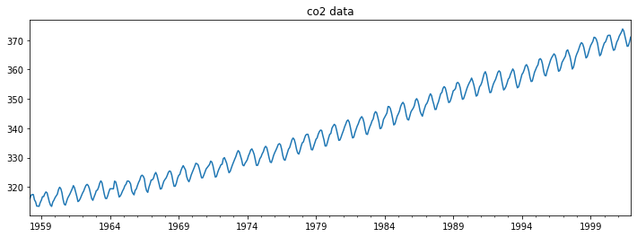

```python
import numpy as np
import pandas as pd
from statsmodels.datasets import co2
from statsmodels.tsa.stattools import adfuller
from matplotlib import pyplot as plt

# 加载数据
data = co2.load(as_pandas=True).data
# 月度数据
data = data['co2']
data = data.resample('M').mean().ffill()

# 可视化
data.plot(figsize=(12,4))
plt.title('co2 data')
plt.show()
```

```python
res = adfuller(data)
print('p value:', res[1])
```

```
p value: 0.9989453312516823
```

从时序图和adf检验的p值都可看出原始的时间序列都不平稳，因为是月度数据，并且存在周期，对数据进行季节差分，即用第二年一月减去第一年一月，以此类推。

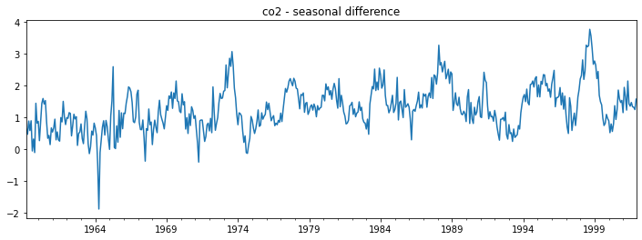

```python
# # 一阶差分
# data_diff1 = data.diff()
# # 二阶差分
# data_diff2 = data_diff1.diff()

# 季节差分
data_diff = data.diff(12).dropna()

data_diff.plot(figsize=(12,4))
plt.title('co2 - seasonal difference')
plt.show()

# ADF检验
res = adfuller(data_diff)
print('p value:', res[1])
```

```
p value: 0.000778539367442881
```

季节差分后，ADF检验中p值为0.0007小于0.05，故而差分后序列平稳。

## 2.2 平滑法

对当前序列值减去平滑值得到一个残差序列，当平滑结果能比较好的描述原始序列趋势特征的时候，残差序列一般是平稳的，后续可对残差序列进行建模预测。计算平滑值的方法可以用简单移动平均、加权移动平均、一次指数平滑、二次指数平滑等。同类思想，还可以拟合一个回归方程，用回归方程描述原始序列的趋势特征。

```python
df = pd.read_csv('pinghuashuju.csv')
df.head()
```

|  | co2 | t |
| --- | --- | --- |
| 0 | 316.100000 | 1 |
| 1 | 317.200000 | 2 |
| 2 | 317.433333 | 3 |
| 3 | 317.433333 | 4 |
| 4 | 315.625000 | 5 |

```python
plt.plot(df['t'],df['co2'])
#plt.show(figsize)
```

```
[<matplotlib.lines.Line2D at 0x2be415919c8>]
```

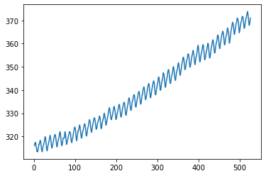

查看原始数据可以看到有趋势，通过线性拟合并将原始数据与拟合后的做差，试图平稳化。

```python
from sklearn import linear_model
```

```python
lr_model =  linear_model.LinearRegression()
lr_model.fit(df[['t']],df['co2'])
```

```
LinearRegression()
```

```python
y_fit = lr_model.predict(df[['t']])
y_res = y_fit - df['co2']
plt.plot(df['t'],y_res)
```

```
[<matplotlib.lines.Line2D at 0x2be427d5088>]
```

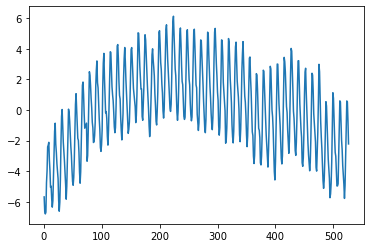